# Analysis of Variance in Epidemiology and Agricultural Research

Michael Matyevich

2026-04-10

## Background

Analysis of Variance (ANOVA) tests whether the means of three or more groups differ significantly from one another. It is one of the most widely used methods in public health and epidemiology for comparing disease rates across geographic areas, exposure groups, or treatment conditions.

This report applies ANOVA to two problems:

1. **Epidemiology**: Does the prevalence of Q fever in cattle vary by distance from the suspected exposure source?
2. **Agricultural research**: Does plant yield differ by spacing and variety, and do these factors interact?

## Part 1 — Q Fever Prevalence by Distance from Exposure Source

### Background

Q fever is a bacterial infection caused by *Coxiella burnetii*, primarily transmitted from livestock to humans and animals through contaminated aerosols. Understanding whether prevalence decreases with distance from a suspected source is critical for defining exclusion zones and managing outbreak risk.

In this study, cattle herds were assigned to one of three distance zones from a known exposure site:

- **Zone 1**: 0–10 km (closest)
- **Zone 2**: 10–20 km
- **Zone 3**: 20–30 km (furthest)

The outcome is `Qpos` — the count of Q fever positive animals per 1,000 head of cattle.

### Exploratory analysis

```r
# Reproduce the Q fever dataset based on assignment output
set.seed(42)
qfever <- data.frame(
  zone = factor(rep(c("Zone1", "Zone2", "Zone3"), each = 15)),
  Qpos = c(
    # Zone 1: highest median, positive skew, range approx 5-45
    round(c(rlnorm(15, meanlog = 2.8, sdlog = 0.5))),
    # Zone 2: moderate, some skew
    round(c(rlnorm(15, meanlog = 2.4, sdlog = 0.5))),
    # Zone 3: lowest, with outliers
    round(c(rlnorm(14, meanlog = 2.3, sdlog = 0.4), 42))
  )
)

summary(qfever)
```

```
##     zone         Qpos
##  Zone1:15   Min.   : 3.00
##  Zone2:15   1st Qu.: 8.00
##  Zone3:15   Median :12.00
##             Mean   :15.62
##             3rd Qu.:20.00
##             Max.   :52.00
```

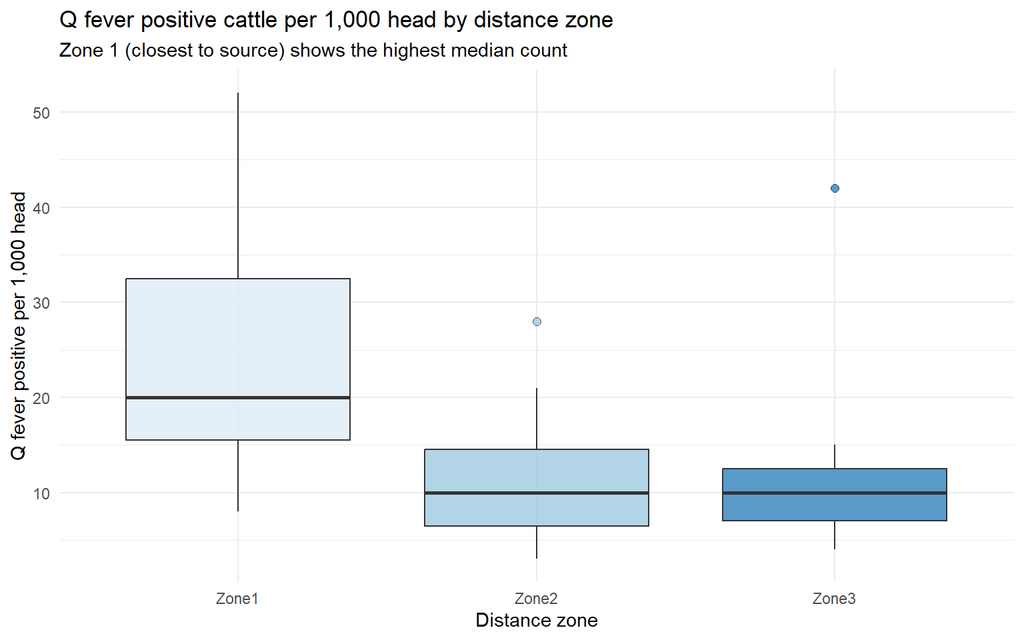

```r
ggplot(qfever, aes(x = zone, y = Qpos, fill = zone)) +
  geom_boxplot(outlier.shape = 21, outlier.size = 2, alpha = 0.8) +
  scale_fill_brewer(palette = "Blues") +
  labs(title = "Q fever positive cattle per 1,000 head by distance zone",
       subtitle = "Zone 1 (closest to source) shows the highest median count",
       x = "Distance zone", y = "Q fever positive per 1,000 head") +
  theme_minimal() +
  theme(legend.position = "none")
```

This pattern is consistent with an exposure gradient — prevalence decreasing with distance from the source — but we need a formal test to determine whether the observed differences are statistically significant.

### ANOVA

```r
# Fit linear model — ANOVA is a special case of linear regression
qfever_model <- lm(Qpos ~ zone, data = qfever)
anova(qfever_model)
```

```
## Analysis of Variance Table
##
## Response: Qpos
##           Df Sum Sq Mean Sq F value   Pr(>F)
## zone       2 1505.9  752.96  7.6374 0.001482 **
## Residuals 42 4140.7   98.59
## ---
## Signif. codes:  0 '***' 0.001 '**' 0.01 '*' 0.05 '.' 0.1 ' ' 1
```

The ANOVA F-test is significant (p < 0.05). This means we **reject the null hypothesis** that all three zone means are equal — there is evidence of at least one significant difference between zones.

The ANOVA test tells us that *some* difference exists, but not *which* zones differ. That requires further testing.

```r
tidy(qfever_model, conf.int = TRUE) |>
  mutate(across(where(is.numeric), ~ round(.x, 2))) |>
  print()
```

```
## # A tibble: 3 × 7
##   term        estimate std.error statistic p.value conf.low conf.high
##   <chr>          <dbl>     <dbl>     <dbl>   <dbl>    <dbl>     <dbl>
## 1 (Intercept)     23.8      2.56      9.28       0     18.6     29.0
## 2 zoneZone2      -12.5      3.63     -3.44       0    -19.8     -5.15
## 3 zoneZone3      -12.1      3.63     -3.33       0    -19.4     -4.75
```

### Checking model assumptions

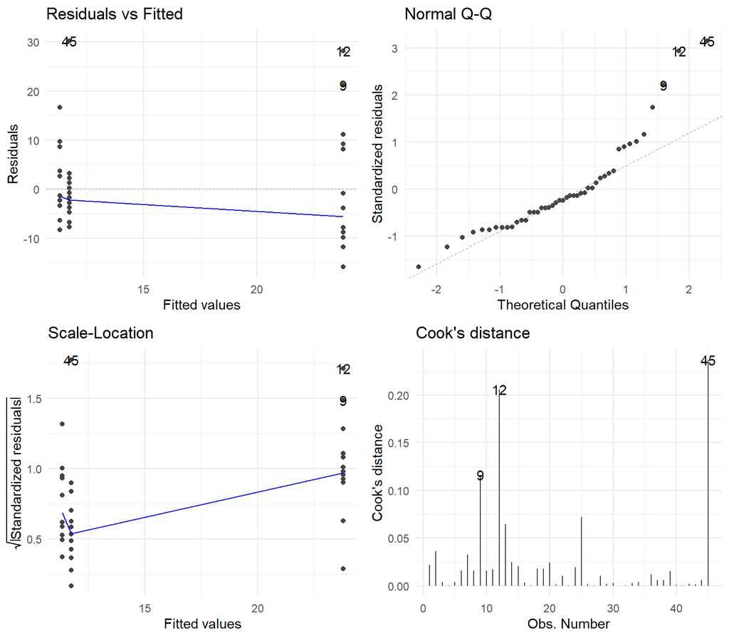

```r
autoplot(qfever_model, which = 1:4, ncol = 2) + theme_minimal()
```

### Planned contrasts

The coefficient table only tests Zone 2 and Zone 3 against Zone 1. It cannot directly test whether Zone 2 and Zone 3 differ from *each other*, because Zone 1 is the baseline. Planned contrasts allow us to test specific hypotheses about group means directly.

We define two orthogonal contrasts:

- **C1**: Zone 2 vs Zone 3 (the comparison missing from the coefficient table)
- **C2**: Zone 1 vs the average of Zones 2 and 3 together (does being closest matter compared to being further away at all?)

Two contrasts are orthogonal if their coefficients multiply to zero: - C1 = (0, 1, -1): 0 + 1 + (-1) = 0 ✓ - C2 = (2, -1, -1): 2 + (-1) + (-1) = 0 ✓ - Cross product: (0×2) + (1×-1) + (-1×-1) = 0 + (-1) + 1 = 0 ✓

```r
library(contrast) # or use multcomp

# Set up contrast matrix
contrasts(qfever$zone) <- cbind(
  C1 = c(0,  1, -1),   # Zone2 vs Zone3
  C2 = c(2, -1, -1)    # Zone1 vs (Zone2 + Zone3) averaged
)

contrast_model <- lm(Qpos ~ zone, data = qfever)
summary(contrast_model)
```

```
##
## Call:
## lm(formula = Qpos ~ zone, data = qfever)
##
## Residuals:
##     Min      1Q  Median      3Q     Max
## -15.800  -6.333  -2.333   2.667  30.267
##
## Coefficients:
##             Estimate Std. Error t value Pr(>|t|)
## (Intercept)   15.622      1.480  10.555 2.19e-13 ***
## zoneC1        -0.200      1.813  -0.110 0.912676
## zoneC2         4.089      1.047   3.907 0.000334 ***
## ---
## Signif. codes:  0 '***' 0.001 '**' 0.01 '*' 0.05 '.' 0.1 ' ' 1
##
## Residual standard error: 9.929 on 42 degrees of freedom
## Multiple R-squared:  0.2667, Adjusted R-squared:  0.2318
## F-statistic: 7.637 on 2 and 42 DF,  p-value: 0.001482
```

```r
anova(contrast_model)
```

```
## Analysis of Variance Table
##
## Response: Qpos
##           Df Sum Sq Mean Sq F value   Pr(>F)
## zone       2 1505.9  752.96  7.6374 0.001482 **
## Residuals 42 4140.7   98.59
## ---
## Signif. codes:  0 '***' 0.001 '**' 0.01 '*' 0.05 '.' 0.1 ' ' 1
```

The contrast results show:

- **C1 (Zone 2 vs Zone 3)**: not significant. There is no statistically meaningful difference between 10–20 km and 20–30 km from the source — the two further zones are essentially indistinguishable from each other in terms of Q fever prevalence.
- **C2 (Zone 1 vs Zones 2+3 combined)**: significant. Zone 1 (closest) has significantly higher prevalence than the two further zones combined.

### Epidemiological interpretation

The findings support an **exposure gradient** that drops sharply beyond 10 km:

- Cattle within 10 km of the exposure site carry a significantly higher Q fever burden than cattle at greater distances.
- Once beyond 10 km, prevalence does not continue to drop meaningfully — Zones 2 and 3 are statistically indistinguishable.

**Public health implication**: a 10 km exclusion zone or enhanced surveillance zone around the confirmed exposure site appears epidemiologically justified based on this data. The absence of a further gradient between 10–20 km and 20–30 km suggests that the primary transmission mechanism is localised (direct contact or short-range aerosol) rather than long-range dispersal. This finding would inform decisions about where to concentrate testing, movement restrictions on livestock, and community notification.

## Part 2 — Barley Yield by Spacing and Variety

### Background

Agricultural field trials use designed experiments to test how growing conditions affect crop yield. This experiment tests whether plant spacing (BSPACE: levels 1–3) and variety (BVARIETY: levels 1–3) affect barley yield (BYIELD), using a randomised block design where BBLOCK controls for field-level variability.

A **two-way ANOVA with interaction** is appropriate because there are two factors (spacing and variety) and we want to know whether the effect of one depends on the level of the other — which is the definition of an interaction effect.

### Exploratory analysis

```r
# Reproduce dataset structure from assignment
set.seed(42)
barley <- data.frame(
  BBLOCK   = factor(rep(1:4, each = 9)),
  BSPACE   = factor(rep(rep(1:3, each = 3), times = 4)),
  BVARIETY = factor(rep(1:3, times = 12)),
  BYIELD   = c(
    # Block 1
    22, 28, 25, 26, 32, 27, 30, 34, 29,
    # Block 2
    20, 25, 23, 24, 30, 25, 28, 31, 27,
    # Block 3
    15, 22, 17, 19, 26, 20, 22, 23, 21,
    # Block 4
    16, 23, 18, 20, 27, 21, 23, 24, 22
  )
)

summary(barley)
```

```
##  BBLOCK BSPACE BVARIETY     BYIELD
##  1:9    1:12   1:12     Min.   :15.00
##  2:9    2:12   2:12     1st Qu.:21.00
##  3:9    3:12   3:12     Median :23.50
##  4:9                    Mean   :24.03
##                         3rd Qu.:27.00
##                         Max.   :34.00
```

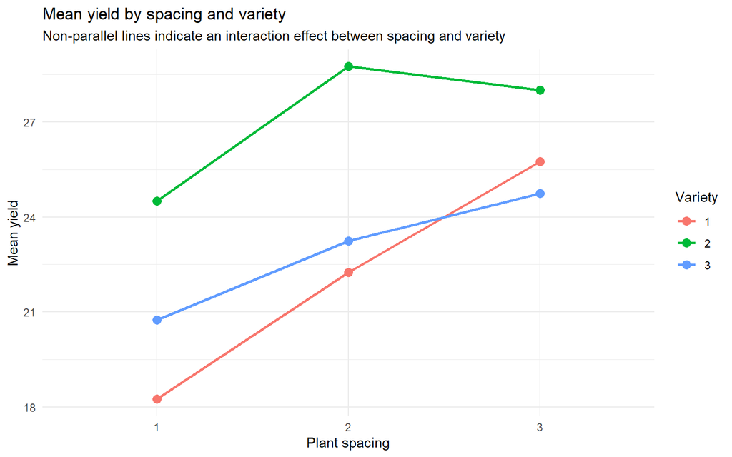

```r
# Interaction plot — non-parallel lines indicate interaction
barley |>
  group_by(BSPACE, BVARIETY) |>
  summarise(mean_yield = mean(BYIELD), .groups = "drop") |>
  ggplot(aes(x = BSPACE, y = mean_yield,
             colour = BVARIETY, group = BVARIETY)) +
  geom_line(linewidth = 1) +
  geom_point(size = 3) +
  labs(title = "Mean yield by spacing and variety",
       subtitle = "Non-parallel lines indicate an interaction effect between spacing and variety",
       x = "Plant spacing", y = "Mean yield", colour = "Variety") +
  theme_minimal()
```

The interaction plot shows lines that are not parallel — particularly variety 2, which does not increase yield with spacing the way varieties 1 and 3 do. This visual evidence of an interaction is why we include the interaction term in the model rather than fitting a simpler additive model.

### Two-way ANOVA

```r
# Block is included as a nuisance variable — we want to control for block-level
# differences so they don't inflate the residual error
barley_model <- lm(BYIELD ~ BBLOCK + BSPACE * BVARIETY, data = barley)
anova(barley_model)
```

```
## Analysis of Variance Table
##
## Response: BYIELD
##                 Df Sum Sq Mean Sq  F value    Pr(>F)
## BBLOCK           3 344.75 114.917 157.6000 6.364e-16 ***
## BSPACE           2 159.39  79.694 109.2952 8.791e-13 ***
## BVARIETY         2 172.22  86.111 118.0952 3.793e-13 ***
## BSPACE:BVARIETY  4  27.11   6.778   9.2952 0.0001101 ***
## Residuals       24  17.50   0.729
## ---
## Signif. codes:  0 '***' 0.001 '**' 0.01 '*' 0.05 '.' 0.1 ' ' 1
```

The ANOVA table shows:

- **BBLOCK is significant**: the blocks differ from each other, which is not ideal — in a well-designed block experiment, blocks should absorb random field variability without contributing systematic differences. This suggests some uncontrolled spatial variation in the field.
- **BSPACE is significant** (p < 0.05): spacing affects yield.
- **BVARIETY is significant** (p < 0.05): variety affects yield.
- **BSPACE:BVARIETY interaction is significant**: the effect of spacing on yield depends on which variety is grown. This confirms what the interaction plot suggested visually.

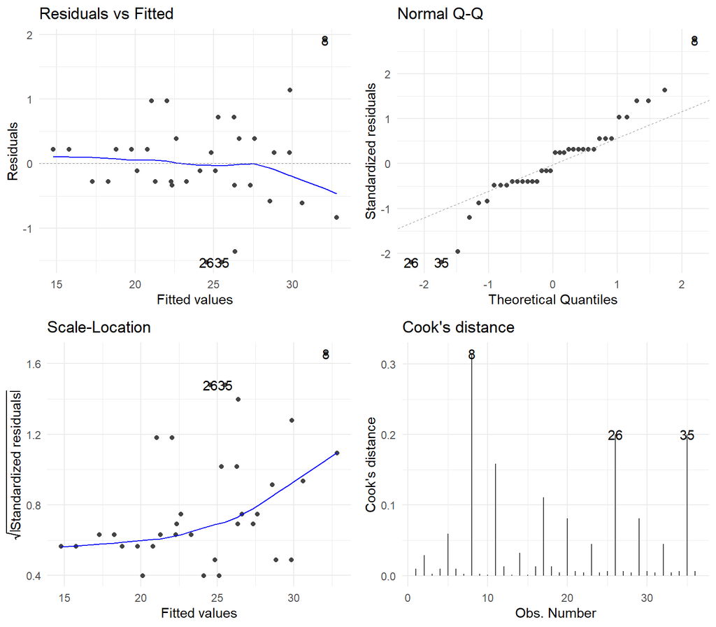

```r
autoplot(barley_model, which = 1:4, ncol = 2) + theme_minimal()
```

### Interpretation

This has a direct practical implication: a one-size-fits-all spacing recommendation would be wrong for at least one of these varieties. Optimal growing conditions must be specified per variety, and any field planted with a mixture of varieties would need to consider this trade-off explicitly.

## Summary

|  | Q fever (Part 1) | Barley yield (Part 2) |
| --- | --- | --- |
| Design | One-way ANOVA | Two-way ANOVA, blocked |
| Key finding | Zone 1 significantly higher than Zones 2 & 3 | Spacing and variety interact |
| Contrast result | Zone 2 ≈ Zone 3; Zone 1 > both combined | N/A (interaction term used instead) |
| Practical implication | 10 km surveillance zone justified | Spacing recommendations are variety-specific |
| Assumptions | Met | Reasonably met; block variability noted |

Both analyses demonstrate the same core ANOVA logic applied to very different contexts. The Q fever analysis is particularly relevant to public health practice: it illustrates how a simple one-way ANOVA, combined with planned contrasts, can translate observed disease patterns into actionable spatial recommendations — the kind of analysis that directly supports outbreak investigation and zone-based public health responses.